# Análisis Estadístico con R - Parte I

##### Distribución Normal Bivariada $\mu=[0,0]$ $\sigma=[5,5]$ $cov=12.5$ $\rho=0.5$

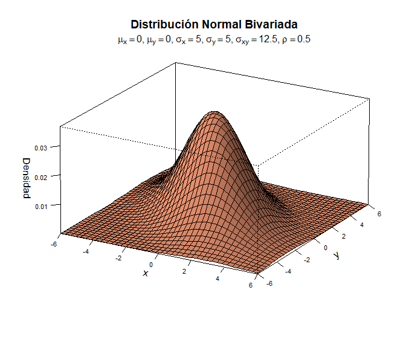

```r
x<-seq(-6,6,length=40);y<-x
z<-outer(x,y,f,s=c(5,12.5,5)) # matriz de densidades

persp(x, y, z,col="lightsalmon",theta=30,phi=20,r=50,d=0.1,expand=0.5,ltheta=90,
      main="Distribución Normal Bivariada",lphi=180,shade=0.3,ticktype="detailed",
      nticks=5,cex.axis=0.7,zlab = 'Densidad')
mtext(expression(list(mu[x]==0,mu[y]==0,sigma[x]==5,sigma[y]==5,
                      sigma[xy]==12.5,rho==0.5)), side=3)
```

##### Distribución Normal Bivariada $\mu=[0,0]$ $\sigma=[5,5]$ $cov=-12.5$ $\rho=-0.5$

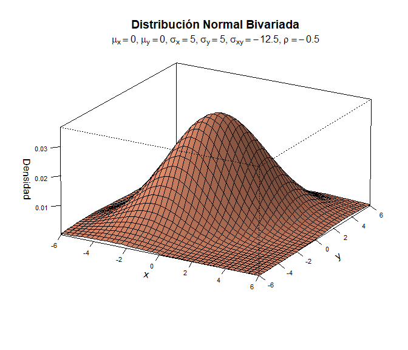

```r
x<-seq(-6,6,length=40);y<-x
z<-outer(x,y,f,s=c(5,-12.5,5)) # matriz de densidades

persp(x, y, z,col="lightsalmon",theta=30, phi=20,r=50,d=0.1,expand=0.5,ltheta=90,
      main="Distribución Normal Bivariada",lphi=180,shade=0.3,ticktype="detailed",
      nticks=5,cex.axis=0.7,zlab = 'Densidad')
mtext(expression(list(mu[x]==0,mu[y]==0,sigma[x]==5,sigma[y]==5,
                      sigma[xy]==-12.5,rho==-0.5)), side=3)
```

##### Distribución Normal Bivariada $\mu=[0,0]$ $\sigma=[5,5]$ $cov=24$ $\rho=0.96$

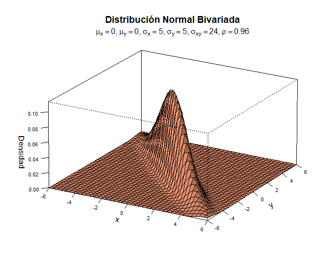

```r
x<-seq(-6,6,length=40);y<-x
z<-outer(x,y,f,s=c(5,24,5)) # matriz de densidades

persp(x, y, z,col="lightsalmon",theta=30, phi=20,r=50,d=0.1,expand=0.5,ltheta=90,
      main="Distribución Normal Bivariada",lphi=180,shade=0.3,ticktype="detailed",
      nticks=5,cex.axis=0.7,zlab = 'Densidad')
mtext(expression(list(mu[x]==0,mu[y]==0,sigma[x]==5,sigma[y]==5,
                      sigma[xy]==24,rho==0.96)), side=3)
```

En este gráfico se puede observar que en la distribucíon normal bivariada cuando la correlación entre las variables es es cercana a 1, la cresta de la superfice es más pronunciada limitando a que las densidades exitan en los puntos críticos donde se cumple $X=Y$.

## Ajustes de Distribuciones de Probabilidad en `R`

Esta es una guía en `R` para evaluar cómo distribuye un conjunto de datos, cuando no se conoce una distribución de probabilidad.

Para este fin es necesario instalar los paquetes `car` y `MASS` con el siguiente comando

```r
install.packages(c("car","MASS"),
                 dependencies = TRUE)
```

Es posible que a medida que se vayan ejecutando los códigos para hacer los análisis, se presenten errores solicitando otros paquetes complementarios. Por fortuna, el `R` indicará qué paquetes harán falta y con el código anterior se pueden instalar.

#### Gráficos

Para determinar si un conjunto de datos tiene una distribución conocida, se realizan pruebas de bondad de ajuste las cuales son parte de los métodos estadísticos inferenciales y no son del alcance de este curso. Sin embargo, se pueden realizar análisis exploratorios con algunos gráficos que ayudan a apreciar de manera aproximada cómo podrían distribuir los datos.

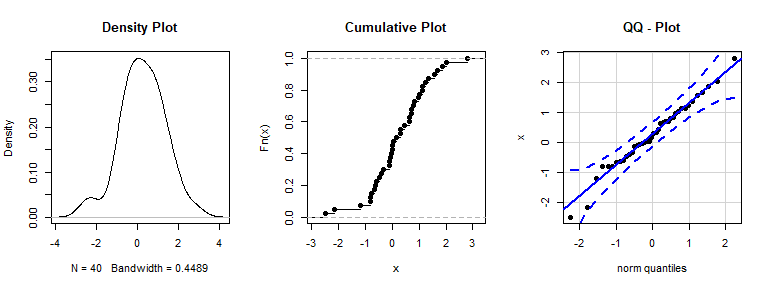

Estos tres gráficos nos ayudarán para explorar el comportamiento de los datos y se pueden combinar con los gráficos de las distribuciones teóricas para evaluar qué tanto se parecen.

El primer gráfico se llama **Gráfico de Densidad**, muestra cómo es la distribución empírica de probabilidad, a diferencia del *Histograma* es una buena aproximación de las distribuciones continuas.

El segundo gráfico se llama **Gráfico Densidad Acumulada Empírica**, este gráfico es muy útil cuando se compara con *La densidad acumulada* de las distribuciones teóricas. Además, el gráfico muestra el salto de cada muestra en la función de densidad acumulada empírica.

El tercer gráfico se llama **Gráfico de Comparación de Cuantiles**, contrasta las muestras con los cuantiles de la distribución teórica. La ventaja de este gráfico es que dibuja una recta en la cual se *espera* que el conjunto de datos se ajuste, además dibuja bandas de confianza para mostrar hasta dónde se puede considerar que los puntos se ajustan a la recta.

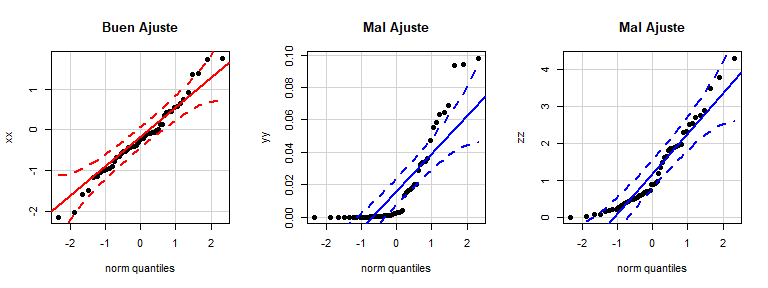

La idea de este gráfico es que los puntos estén muy cercanos a la recta y entre los límites de confianza. Hay que tener cuidado en los extremos de las muestras, ya que algunos puntos pueden salir de las bandas pero esto no significa que no tengan la distribución que se está evaluando; si la mayoría de los puntos están ajustados a la recta y son muy pocos datos **en los extremos** que salen de las bandas, se puede considerar un buen ajuste.

#### Estimación de parámetros

Para estimar los parámetros de una distribución utilizaremos la función `fitdistr` del paquete `MASS`.

```
## function (x, densfun, start, ...)
```

Esta función recibe el conjunto de datos, se establece la función de distribución de probabilidad y en algunos casos se establece los valores iniciales de los parámetros para que realice el ajuste. Para más información consulte la ayuda `?fitdistr`.

```r
x <- rnorm(n = 40,mean = 50,sd = 10)
fitdistr(x,"normal")
```

```
##       mean          sd
##   49.6620793    8.6775237
##  ( 1.3720370) ( 0.9701766)
```

Al aplicar la función, estima los parámetros de la distribución teórica de la cual se tiene sospecha, junto con los errores de estimación. La idea de esta estimación, es usar esos estadísticos para hacer las evaluaciones gráficas para contrastar las muestras con las distribuciones teóricas.

**Los ejemplos que se presentarán a continuación son simulaciones de variables aleatorias, y los resultados ajustan a las distribuciones evaluadas.**

#### Distribución poisson

```r
x <- rpois(n = 40,lambda = 5)
(param <- fitdistr(x,densfun = "Poisson"))
```

```
##     lambda
##   5.6500000
##  (0.3758324)
```

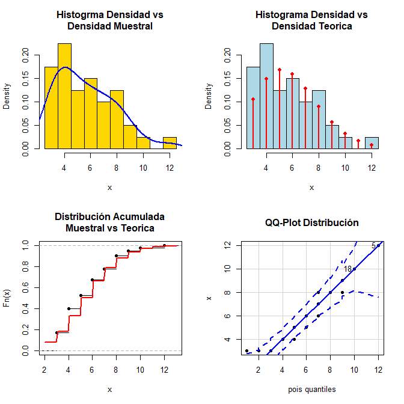

```
## [1]  5 18
```

```r
par(mfrow=c(2,2))

hist(x,freq = F,col="gold",breaks = seq(-0.5+min(x),max(x)+0.5),
     main = "Histogrma Densidad vs\nDensidad Muestral")
lines(density(x),col=4,lwd=2)

hist(x,freq = F,col="lightblue",breaks = seq(-0.5+min(x),max(x)+0.5),
     main = "Histograma Densidad vs\nDensidad Teorica")
lines(seq(min(x),max(x)+0.5,by=1),
      dpois(seq(min(x),max(x)+0.5,by=1),lambda = param$estimate),
      col=2,lwd=2,type='h')
points(seq(min(x),max(x)+0.5,by=1),
       dpois(seq(min(x),max(x)+0.5,by=1),lambda = param$estimate)
       ,col=2,pch=19)

plot(ecdf(x),main="Distribución Acumulada\nMuestral vs Teorica")
curve(ppois(x,lambda = param$estimate),col=2,lwd=2,add=T)

qqPlot(x,distribution = "pois",lambda = param$estimate,pch=19,
       main="QQ-Plot Distribución")
```

#### Distribución Exponencial

```r
x <- rexp(n = 40, rate = 8)
(param <- fitdistr(x,densfun = "exponential"))
```

```
##      rate
##   7.489342
##  (1.184169)
```

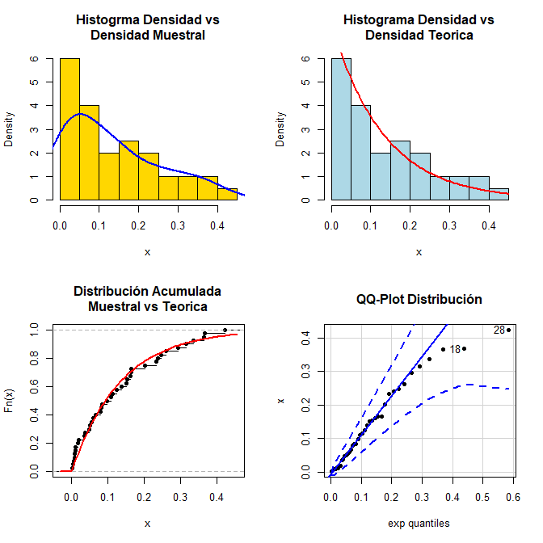

```
## [1] 28 18
```

```r
par(mfrow=c(2,2))
hist(x,freq = F,col="gold",main = "Histogrma Densidad vs\nDensidad Muestral")
lines(density(x),col=4,lwd=2)

hist(x,freq = F,col="lightblue",main = "Histograma Densidad vs\nDensidad Teorica")
curve(dexp(x,rate = param$estimate),col=2,lwd=2,add=T)

plot(ecdf(x),main="Distribución Acumulada\nMuestral vs Teorica")
curve(pexp(x,rate = param$estimate),col=2,lwd=2,add=T)

qqPlot(x,distribution = "exp",rate = param$estimate,pch=19,
       main="QQ-Plot Distribución")
```

#### Distribución Normal

```r
x <- rnorm(n = 50, mean = 8, sd = 5)
(param <- fitdistr(x,densfun = "normal"))
```

```
##      mean         sd
##   7.8114222   4.4795092
##  (0.6334983) (0.4479509)
```

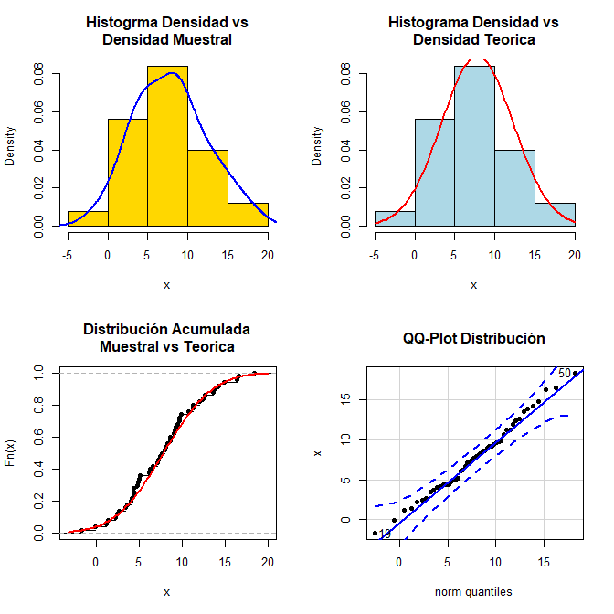

```
## [1] 50 19
```

```r
par(mfrow=c(2,2))
hist(x,freq = F,col="gold",main = "Histogrma Densidad vs\nDensidad Muestral")
lines(density(x),col=4,lwd=2)

hist(x,freq = F,col="lightblue",main = "Histograma Densidad vs\nDensidad Teorica")
curve(dnorm(x,mean = param$estimate[1], sd = param$estimate[2]),col=2,lwd=2,add=T)

plot(ecdf(x),main="Distribución Acumulada\nMuestral vs Teorica")
curve(pnorm(x,mean = param$estimate[1],sd = param$estimate[2]),col=2,lwd=2,add=T)

qqPlot(x,distribution = "norm",mean = param$estimate[1],sd = param$estimate[2],
       pch=19,main="QQ-Plot Distribución")
```

#### Distribución Log-Normal

```r
x <- rlnorm(n = 50, meanlog = 4, sdlog = 0.75)
(param <- fitdistr(x,densfun = "lognormal"))
```

```
##     meanlog       sdlog
##   3.87452168   0.73623560
##  (0.10411944) (0.07362356)
```

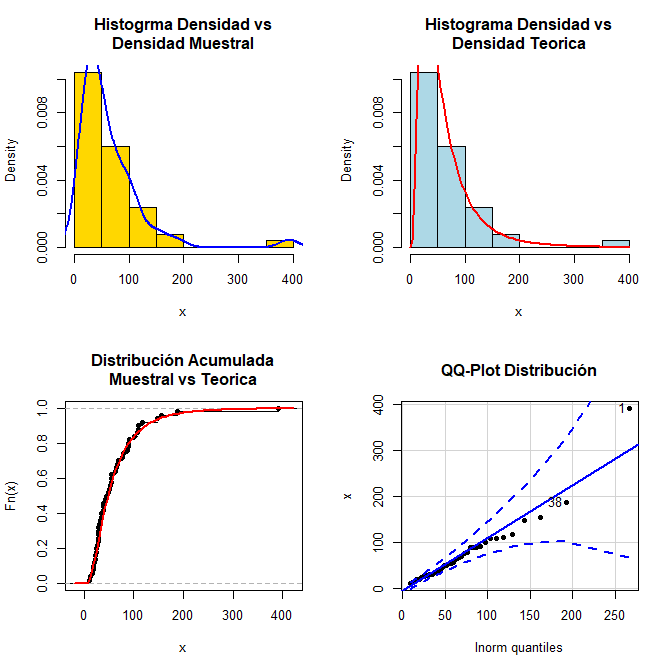

```
## [1]  1 38
```

```r
par(mfrow=c(2,2))
hist(x,freq = F,col="gold",main = "Histogrma Densidad vs\nDensidad Muestral")
lines(density(x),col=4,lwd=2)

hist(x,freq = F,col="lightblue",main = "Histograma Densidad vs\nDensidad Teorica")
curve(dlnorm(x,meanlog = param$estimate[1], sdlog = param$estimate[2]),col=2,
      lwd=2,add=T)

plot(ecdf(x),main="Distribución Acumulada\nMuestral vs Teorica")
curve(plnorm(x,meanlog = param$estimate[1],sdlog = param$estimate[2]),col=2,
      lwd=2,add=T)

qqPlot(x,distribution = "lnorm",meanlog = param$estimate[1],
       sdlog = param$estimate[2],
       pch=19,main="QQ-Plot Distribución")
```

#### Distribución Gamma

```r
x <- rgamma(n = 50,shape = 2, rate = 1/4)
(param <- fitdistr(x,densfun = "gamma"))
```

```
##      shape         rate
##   2.00321400   0.26891664
##  (0.37210344) (0.05671988)
```

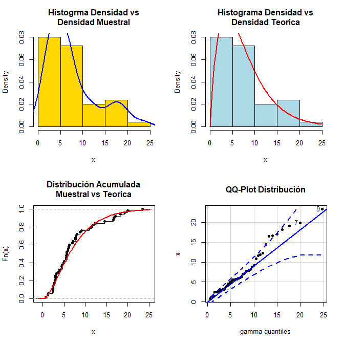

```
## [1] 9 7
```

```r
par(mfrow=c(2,2))
hist(x,freq = F,col="gold",main = "Histogrma Densidad vs\nDensidad Muestral")
lines(density(x),col=4,lwd=2)

hist(x,freq = F,col="lightblue",main = "Histograma Densidad vs\nDensidad Teorica")
curve(dgamma(x,shape = param$estimate[1], rate = param$estimate[2]),col=2,
      lwd=2,add=T)

plot(ecdf(x),main="Distribución Acumulada\nMuestral vs Teorica")
curve(pgamma(x,shape = param$estimate[1],rate = param$estimate[2]),col=2,
      lwd=2,add=T)

qqPlot(x,distribution = "gamma",shape = param$estimate[1],rate = param$estimate[2],
       pch=19,main="QQ-Plot Distribución")
```

#### Distribución Beta

Para la distribución beta, es necesario establecer los valores iniciales para estimar los parámetros con la función `fitdistr`, esto se hace en el argumento `start` ingresando una lista con los parámetros de la distribución.

```r
x <- rbeta(n = 50,shape1 = 9,shape2 = 2)
(param <- fitdistr(x,densfun = "beta",
                   start = list(shape1=0.1,shape2=0.1)))
```

```
##     shape1      shape2
##   9.8619501   2.2544047
##  (2.0136666) (0.4224247)
```

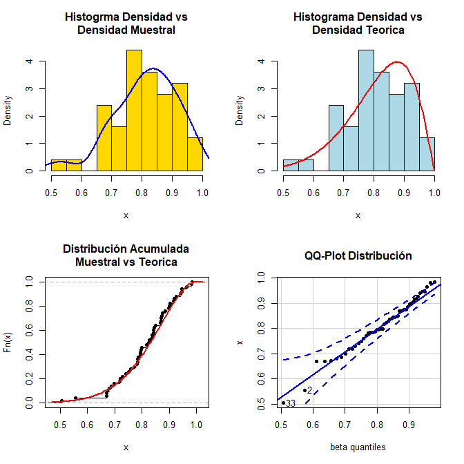

```
## [1] 33  2
```

```r
par(mfrow=c(2,2))
hist(x,freq = F,col="gold",main = "Histogrma Densidad vs\nDensidad Muestral")
lines(density(x),col=4,lwd=2)

hist(x,freq = F,col="lightblue",main = "Histograma Densidad vs\nDensidad Teorica")
curve(dbeta(x,shape1 = param$estimate[1], shape2 = param$estimate[2]),col=2,
      lwd=2,add=T)

plot(ecdf(x),main="Distribución Acumulada\nMuestral vs Teorica")
curve(pbeta(x,shape1 = param$estimate[1],shape2 = param$estimate[2]),col=2,
      lwd=2,add=T)

qqPlot(x,distribution = "beta",shape1 = param$estimate[1],shape2 = param$estimate[2],
       pch=19,main="QQ-Plot Distribución")
```

#### Comentario final

Tengan en cuenta que para cada ajuste es necesario trabajar con todos los parámetros y argumentos de las funciones de distribución. En particular la función `qqPlot` no trae por defecto valores para los parámetros de las funciones, es necesario ingresarlas y **deben tener los mismos nombres** de los argumentos que reciben las funciones básicas de las distribuciones (`rnorm`, `rbeta`, `rgamma`, etc…).

## Estimación

En la práctica, cuando se estiman parámetros a través de los datos es necesario tener un rango de posibles valores para el parámetro de interés, es decir, un intervalo real donde se cree que estará el valor del parámetro con una alta confianza.

Sea $X$ una variable aleatoria con función de densidad $f(X;\theta)$ con $\theta \in \Omega$, ahora $\theta$ es desconocido y se puede estimar por medio de un estadístico $T=T(X_1,X_2,...,X_n)$ donde $X_1,X_2,...,X_n$ es una muestra de la distribución de $X$. Cuando la muestra es extraída, es poco probable que el valor de $T$ sea el verdadero valor del parámetro.

Supongamos que $\theta_0$ denota el verdadero valor del parámetro desconocido $\theta$ y $T$ es un estimador de $\theta_0$ tal que:

$$\sqrt{n}(T-\theta_0) \quad \xrightarrow[ ]{D} \quad N(0,\sigma_T^{2})$$

El parámetro $\sigma_T^{2}$ es la varianza asintótica de $\sqrt{n}T$ y en la práctica, éste es usualmente desconocido. Por el momento, supondremos que $\sigma_T^{2}$ es conocido.

Sea $Z=\sqrt{n}(T-\theta_0)/\sigma_T$ una variable aleatoria estandarizada, entonces $Z$ es asintóticamente una $N(0,1)$. Por lo tanto:

$$\begin{aligned}
0.95 =& P(-1.96<Z<1.96) \\
=& P\left( -1.96< \cfrac{\sqrt{n}(T-\theta_0)}{\sigma_T}<1.96\right) \\
=& P\left( T-1.96\cfrac{\sigma_T}{\sqrt{n}}<\theta_0<T+1.96\cfrac{\sigma_T}{\sqrt{n}}\right)
\end{aligned}$$

Se tiene que $(T-1.96(\sigma_T/\sqrt{n});T+1.96(\sigma_T/\sqrt{n}))$ es una función de la variable aleatoria $T$ y se le conoce como **intervalo aleatorio**, y de este resultado se obtiene que la probabilidad de que el intervalo contenga el verdadero valor de $\theta$ es aproximadamente $0.95$.

Sea $t$ el valor del estadístico $T$ cuando se obtiene la muestra, entonces el intervalo aleatorio está dado por:

$$\left(t-1.96\cfrac{\sigma_T}{\sqrt{n}};t+1.96\cfrac{\sigma_T}{\sqrt{n}}\right)$$

Este intervalo puede o no contener el valor del parámetro $\theta_0$. En la práctica $\sigma_T$ a menudo es desconocido, supongamos que el estadístico $S_t$ es un estimador consistente de $\sigma_T$.

$$\frac{\sqrt{n}(T-\theta_0)}{s_t} \xrightarrow[ ]{D} N(0,1)$$

Entonces el intervalo queda de la siguiente manera:

$$\left(T-1.96\cfrac{S_T}{\sqrt{n}};T+1.96\cfrac{S_T}{\sqrt{n}}\right)$$

Luego de extraida la muestra un intervalo de confianza al 95$\%$ para $\theta_0$ es:

$$\left(t-1.96\cfrac{S_T}{\sqrt{n}};t+1.96\cfrac{S_T}{\sqrt{n}}\right)$$

Nota: $\frac{S_T}{\sqrt{n}}$ es llamado error estandar de $T$.

### Intervalo de confianza para $\mu$

Sean $X_1,X_2,...,X_n$ una muestra aleatoria para la variable $X$, donde $\mu$ y $\sigma^2$ son desconocidos. Sean $\overline{X}$ y $S^2$ las estimaciones de la media y la varianza respectivamente. Sabemos que $\frac{\sqrt{n}(\overline{X}-\mu)}{S}$ es aproximadamente una N(0,1).

Un I.C del 95$\%$ para $\mu$ está dado por:

$$\left(\overline{X}-1.96\frac{S}{\sqrt{n}},\overline{X}+1.96\frac{S}{\sqrt{n}}\right)$$

Ahora consideremos un coeficiente de confianza de $(1-\alpha)100\%$ para $\mu$ donde $0<\alpha<1$. Se define $z_{\frac{\alpha}{2}}$ como el cuantil superior $\frac{\alpha}{2}$ de una variable aleatoria normal estandar; es decir, $1-\Phi(z_{\frac{\alpha}{2}})=\frac{\alpha}{2}$, donde $\Phi(z)$ es la función de distribución de una normal estandar. Entonces un I.C del $(1-\alpha)100\%$ para $\mu$ es:

$$\left(\overline{X}-Z_{\frac{a}{2}}\frac{S_T}{\sqrt{n}},\overline{X}+Z_{\frac{a}{2}}\frac{S_T}{\sqrt{n}}\right)$$

Vía simulación, se plantean los siguientes pasos para obtener intervalos de confianza aleatorios para una distribución normal estándar:

1. Se genera muestras aleatorias de una distribución normal con $\mu = 0$ y $\sigma=1$, con tamaños de muestra $n=[50,80,100,1000]$.
2. Se establece un nivel de significancia $\alpha=0.05$, es decir una confianza del 95%.
3. Se calcula el promedio para cada $n$.
4. Se calcula el intervalo de confianza para $\mu$ para cada $n$.
5. Se chequea si el intervalo contiene o no el verdadero valor del parámetro y se colorea de acuerdo al caso.
- Si contiene el parámetro el color será negro.
- Si el intervalo no contiene el parámetro y el lado inferior está por encima de $\mu$ se pinta de naranjado.
- Si el intervalo no contiene el parámetro y el lado superior está por debajo de $\mu$ se pinta de azul.
6. Se repite el procedimiento 100 veces, para calcular 100 intervalos.
7. Se grafican los resultados.

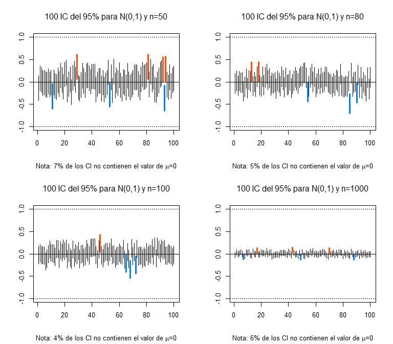

Notas:

1. Dado que $a<a^*$ implica que $z_{\frac{a}{2}}>z_{\frac{a^*}{2}}$, selecionar valores grandes para el coeficiente de confianza conduce a grandes términos de error y por lo tanto, intervalos de confianza amplios, suponiendo que todo lo demás permace igual.
2. Seleccionar un tamaño de muestra grande, decrece el término de error, conduce a intervalos de confianza más precisos, suponiendo que todo lo demás permace igual.
3. Usualmente el parámetro $\sigma_T$ es un tipo de parámetro de escala subyacente a la distribución y del cual depende la amlitud del intervalo. Para valores grandes de $\sigma_T$ se obtienen intervalos poco precisos y viceversa.

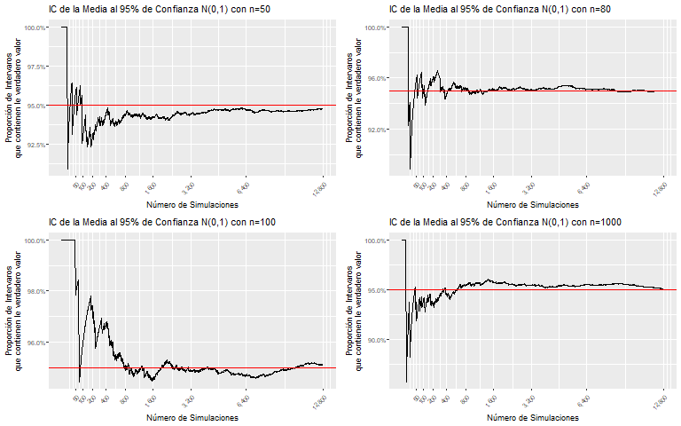

### Intervalo de confianza para $p$

Sea $X$ una $v.a$ Bernoulli con probabilidad de suceso $p$. Suponga que $X_1,X_2,...,X_n$ es una muestra aletoria para la distribución de $X$. Sea $\hat{p}=\overline{X}$ la proporción de muestras de éxitos. Por TLC $\hat{p}$ tiene una distribución aproximadamente $N(p,p(1-p)/n)$. Por la ley débil de los grandes números $\hat{p}$ es un estimador consistente para $p$. Además $\hat{p}(1-\hat{p})$ es un estimador consistente para $p(1-p)$. Por tanto una aproximación para un intervalo de confianza para $p$ al $(1-\alpha)100\%$ esta dado por:

$$(\hat{p}-z_{\frac{\alpha}{2}}\sqrt{\hat{p}(1-\hat{p})/n},\hat{p}+z_{\frac{\alpha}{2}}\sqrt{\hat{p}(1-\hat{p})/n})$$

Donde $\sqrt{\hat{p}(1-\hat{p})/n}$ es llamado el error estandar de $\hat{p}$.

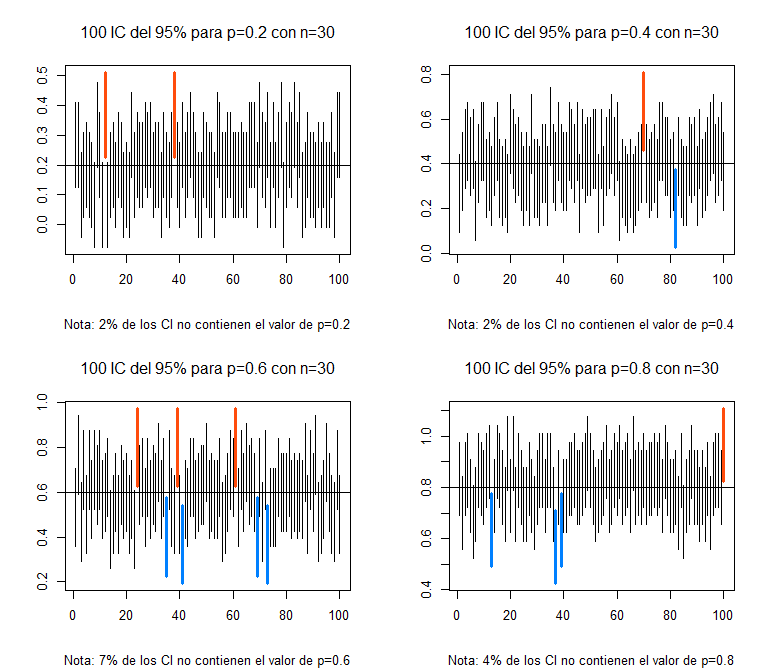

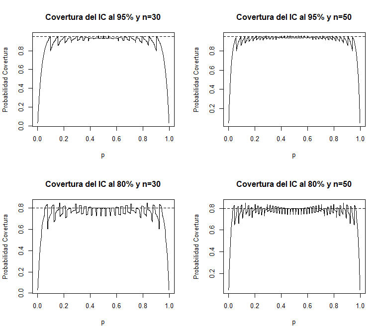

### Intervalo de confiaza para $\mu$ bajo normalidad

Sunponga que $X_1,X_2,...,X_n$ es una $m.a$ de una $N(\mu,\sigma^2)$. Si $\sigma^2$ en conocido se sabe que:

$$\frac{\overline{X}-\mu}{\frac{\sigma}{\sqrt{n}}} ~ N(0,1)$$

Pero si $\sigma$ es desconocida, la distribución de $\overline{X}$ estandarizada NO es normal. Si en la expresión anterior, reemplazamos $\sigma$ por $S$, el estadítstico resultante es:

$$T=\frac{\overline{X}-\mu}{\frac{S}{\sqrt{n}}}~t(n-1)$$

cuya distribución tiene propiedades similares a la de la normal estándar, pero con colas más pesadas ó más alargadas. Por tanto una aproximación para un intervalo de confianza para $\mu$ al $(1-\alpha)100\%$ esta dado por:

$$(\overline{X}-t_{\frac{\alpha}{2},n-1}\frac{S}{\sqrt{n}}, \overline{X}+t_{\frac{\alpha}{2},n-1}\frac{S}{\sqrt{n}})$$

## Pruebas de Hipótesis

Además de la estimación puntual y los intervalos de confianza, la prueba de hipótesis es otro método de inferencia estadística. Supongamos que nuestro interés está sobre la $v.a$ $X~f(x,\theta)$, $\theta \in \Omega$. ($\theta$ desconocido), y según experimentos previos $\theta \in W_0$ o $\theta \in W_1$, donde $W_0$ $U$ $W_1$= $\Omega$. Planteamos las siguientes hipotesis:

$$H_0: \theta \in W_o$$
$$vs$$
$$H_1: \theta \in W_1$$

$H_0$ y $H_a$ se conocen como hipótesis nula y alternativa respectivamente. La decisión de aceptar $H_o$ ó $H_1$ se basa en una $m.a$ $X_1,X_2,...,X_n$ de la distribución de $X$, por tanto la decisión podría ser equivocada. Los errores que se pueden cometer son:

- Aceptar $H_o$ siendo falsa.
- Rechazar $H_o$ siendo verdadera.

| Decisión | $H_0$ es Verdadera | $H_0$ es Falsa |
| --- | --- | --- |
| Rechazar $H_0$ | **Error Tipo I** | Decisión Correcta |
| Aceptar $H_0$ | Decisión Correcta | **Error Tipo II** |

Es lógico que se desea minimizar las probabilidades de cometer los errores en la decisión (tipo 1 ó 2), pero esto depende de la m.a $X_1,X_2,...,X_n$. Sin embargo, si P(cometer error tipo 1)=0, entonces P(cometer error tipo 2)=1. Pero, la prueba $H_0$ vs $H_1$ se basa en un subconjunto $c$ de $D=(X_1,X_2,...,X_n)$ conjunto de todas las posibles muestras de tamaño n. Este conjunto $c$ se llama región crítica y su regla de decisión es:

- Rechazar $H_0$ si $(X_1,X_2,...,X_n) \in C$
- Rechazar $H_0$ si $(X_1,X_2,...,X_n) \in C^c$

Decimos que una región crítica $C$ es de tamaño $\alpha$ si:

$$\alpha=max P_{\theta}[(X_1,X_2,...,X_n) \in C]$$
con $\theta \in W_0$. Así, sobre todas las regiones críticas de tamaño $\alpha$, queremos considerar aquella la cual tenga la menor probabilidad de cometer el error tipo 2.

Minimizar P[error tipo 2] equivale a minimizar $P_{\theta}[(X_1,X_2,...,X_n) \in C]$ = 1-$P_{\theta}$[error tipo 2], que es la potencia de la prueba. Así, podemos definir con mas detalle la potencia de una región crítica como:

$\gamma_c(\theta)=P_{\theta}[(X_1,X_2,...,X_n) \in C]$, $\theta \in W_1$

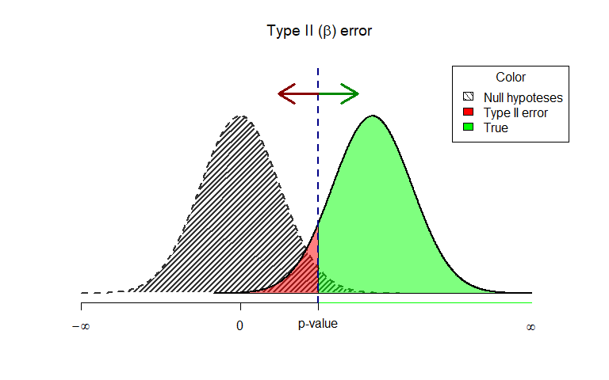

### Ejemplo

La siguiente base de datos contiene información acerca de incautaciones de bebidas alcohólicas fraudulentas y de contrabando en la ciudad de Medellín en un mes, que afectan los recursos para Salud y Educación en el Departamento de Antioquia y de acuerdo a los resultados se toma decisiones para aumentar o disminuir los controles.

Licores

La base de datos contiene las variables - **TL** (Tipo de Licor) - **PI** (Precio de incautación: se refiere al precio de venta en el establecimiento por unidad) - **GAE** (Grados de Alcohol en etiqueta) - **GAQ** (grados de alcohol en prueba química) - **CE** (Cantidades estandarizadas: número de unidades estandarizadas a 750 ml).

Usando la información de su base de datos responda a las siguientes preguntas.

1. El **precio total** de la incautación se calcula como la cantidad estandarizada por el precio de incautación. ¿Se puede afirmar que el precio total promedio de la incautación es superior a $7’500.000?
2. El **ipoconsumo**, es el impuesto que deja de percibir el Estado para salud y educación, el cual se calcula como: $GAQ \times CE \times 400$ (pesos). ¿Se puede afirmar que el ipoconsumo promedio del ron es inferior al ipoconsumo medio del Whisky? ¿Qué decisión se puede tomar frente al control?
3. El licor incautado se clasifica como “Fraudulento” si los GAE son distintos a los GAQ y como “contrabando” si son iguales. ¿La proporción de licores fraudulentos es superior al 65%? ¿Qué significa éste resultado?

#### Solución usando R

Lo primero es descargar la base de datos en la carpeta que se considere, luego debemos cargar la base de datos en `RStudio` para realizar los análisis. Antes de comenzar con el análisis necesitamos instalar o cargar las librerías necesarias para el análisis

```r
# Para manipular datos
if(!require(dplyr)) install.packages("dplyr")
# Gráficos con estilo
if(!require(ggplot2)) install.packages("ggplot2")
# Pruebas de bondad de ajuste
if(!require(nortest)) install.packages("nortest")
# Gráficos QQ-plot con IC
if(!require(car)) install.packages("car")
# Importar/Exportar datos de Excel
if(!require(openxlsx)) install.packages("openxlsx")
```

El siguiente paso es cargar la base de datos, esto lo podemos realizar directamente de `RStudio` con el siguiente comando:

```r
Licores <- read.xlsx(file.choose(),sheet = 1)
```

```r
Licores <- read.xlsx("Licores.xlsx",sheet = 1)
```

Revisemos la estructura de los datos, para verificar si fueron cargados correctamente.

```r
str(Licores)
```

```
## 'data.frame':    300 obs. of  5 variables:
##  $ TL : chr  "Ron" "Aguardiente" "Ron" "Aguardiente" ...
##  $ PI : num  34719 26900 27062 29317 32471 ...
##  $ GAE: num  35 29 35 29 38 29 29 38 35 40 ...
##  $ GAQ: num  30.2 29 32.2 29 32.6 ...
##  $ CE : num  221 253 249 254 267 ...
```

```r
# cambiando caracter por factor
Licores <- Licores %>% mutate_if(is.character,as.factor)
```

El primer punto nos piden calcular **el precio total** de incautación, y se pregunta si el promedio de esa nueva variable es superior a 7.5 millones. Entonces tenemos las hipótesis:

$$H_o: \mu_{pt} = 7'500.000 \qquad H_a:\mu_{pt} > 7'500.000$$

Para seleccionar el estadístico de prueba más indicado, debemos probar si la distribución del precio total de incautación es Normal.

$$H_0:PT \sim N(\mu,\sigma^2) \qquad H_a: PT\not\sim N(\mu,\sigma^2)$$

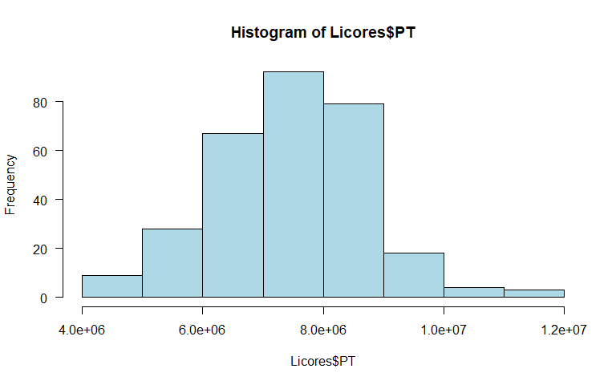

```r
Licores$PT <- Licores$CE*Licores$PI
hist(Licores$PT,col="lightblue",las=1)
```

```r
# pruebas de hipótesis
shapiro.test(Licores$PT)
```

```
##
##  Shapiro-Wilk normality test
##
## data:  Licores$PT
## W = 0.99485, p-value = 0.4134
```

```r
ad.test(Licores$PT)
```

```
##
##  Anderson-Darling normality test
##
## data:  Licores$PT
## A = 0.25534, p-value = 0.7249
```

```r
lillie.test(Licores$PT)
```

```
##
##  Lilliefors (Kolmogorov-Smirnov) normality test
##
## data:  Licores$PT
## D = 0.032027, p-value = 0.6393
```

```r
t.test(Licores$PT,mu = 7500000,alternative = "greater",conf.level = 0.95)
```

```
##
##  One Sample t-test
##
## data:  Licores$PT
## t = -0.42571, df = 299, p-value = 0.6647
## alternative hypothesis: true mean is greater than 7500000
## 95 percent confidence interval:
##  7348999     Inf
## sample estimates:
## mean of x
##   7469031
```

En la siguiente pregunta se pide calcular el *ipoconsumo* de acuerdo a una formulación, y luego comparar si el impuesto de los licores de tipo *Ron* son menores a los de *Whisky* basado en los promedios. Entonces tenemos la siguiente hipótesis:

$$H_0: \mu_{Ir} = \mu_{Iw} \qquad H_a:\mu_{Ir} < \mu_{Iw}$$

De acuerdo al árbol de decisión tenemos que hacer los siguientes pasos:

- Calcular el ipoconsumo
- Separar la base de datos en Ron y Whisky
- Probar la normalidad de ambos grupos
- Comprobar la igualdad de varianzas de los grupos
- Escoger el mejor estadístico de prueba y realizar el análisis.
- Concluir

Los primeros dos pasos son sencillos:

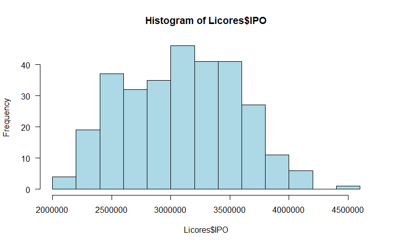

```r
Licores <- Licores %>%
   mutate(IPO = GAQ*CE*400)
hist(Licores$IPO,col="lightblue",las=1)
```

```r
SoloRW <- Licores %>%
   filter(TL %in% c("Ron","Whisky")) %>%
   droplevels
SoloRW %>% group_by(TL) %>%
   summarise(n=length(IPO),
             media=mean(IPO),
             desv=sd(IPO))
```

| TL | n | media | desv |
| --- | --- | --- | --- |
| Ron | 52 | 3185673 | 270971.2 |
| Whisky | 27 | 3591694 | 317110.5 |

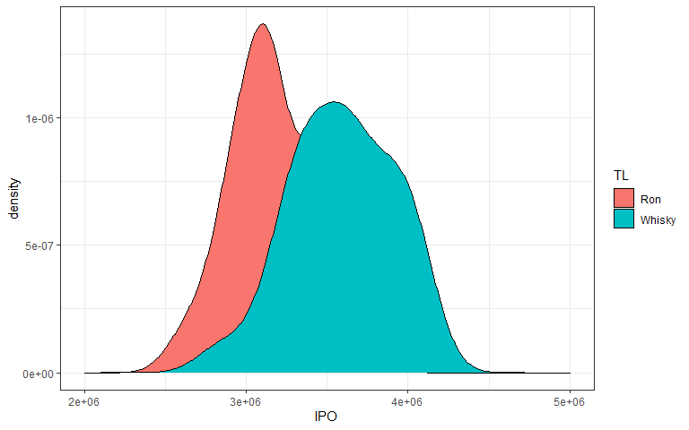

```r
SoloRW %>% ggplot(aes(x=IPO,fill=TL))+
   geom_density()+xlim(c(2e06,5e06))+theme_bw()
```

Luego debemos probar la normalidad de los datos, esto lo podemos hacer de dos formas. La primera es separar la base de datos y construir dos nuevas con los grupos de interés, la otra es evaluar al mismo tiempo los valores-p de las pruebas usando `dplyr`.

```r
# Primer método - Ron
SoloRW %>% filter(TL=="Ron") %>%
   dplyr::select(IPO) %>% unlist %>% shapiro.test()
```

```
##
##  Shapiro-Wilk normality test
##
## data:  .
## W = 0.96894, p-value = 0.1904
```

```r
SoloRW %>% filter(TL=="Ron") %>%
   dplyr::select(IPO) %>% unlist %>% ad.test()
```

```
##
##  Anderson-Darling normality test
##
## data:  .
## A = 0.50493, p-value = 0.1943
```

```r
SoloRW %>% filter(TL=="Ron") %>%
   dplyr::select(IPO) %>% unlist %>% lillie.test()
```

```
##
##  Lilliefors (Kolmogorov-Smirnov) normality test
##
## data:  .
## D = 0.095664, p-value = 0.2758
```

```r
# Primer método - Whisky
SoloRW %>% filter(TL=="Whisky") %>%
   dplyr::select(IPO) %>% unlist %>% shapiro.test()
```

```
##
##  Shapiro-Wilk normality test
##
## data:  .
## W = 0.96678, p-value = 0.5193
```

```r
SoloRW %>% filter(TL=="Whisky") %>%
   dplyr::select(IPO) %>% unlist %>% ad.test()
```

```
##
##  Anderson-Darling normality test
##
## data:  .
## A = 0.26387, p-value = 0.671
```

```r
SoloRW %>% filter(TL=="Whisky") %>%
   dplyr::select(IPO) %>% unlist %>% lillie.test()
```

```
##
##  Lilliefors (Kolmogorov-Smirnov) normality test
##
## data:  .
## D = 0.087079, p-value = 0.8639
```

```r
# Segundo método
SoloRW %>% group_by(TL) %>%
   summarise(valor_p=shapiro.test(IPO)$p.val)
```

| TL | valor_p |
| --- | --- |
| Ron | 0.1904000 |
| Whisky | 0.5192824 |

```r
SoloRW %>% group_by(TL) %>%
   summarise(valor_p=ad.test(IPO)$p.val)
```

| TL | valor_p |
| --- | --- |
| Ron | 0.1942686 |
| Whisky | 0.6710196 |

```r
SoloRW %>% group_by(TL) %>%
   summarise(valor_p=lillie.test(IPO)$p.val)
```

| TL | valor_p |
| --- | --- |
| Ron | 0.2758015 |
| Whisky | 0.8639118 |

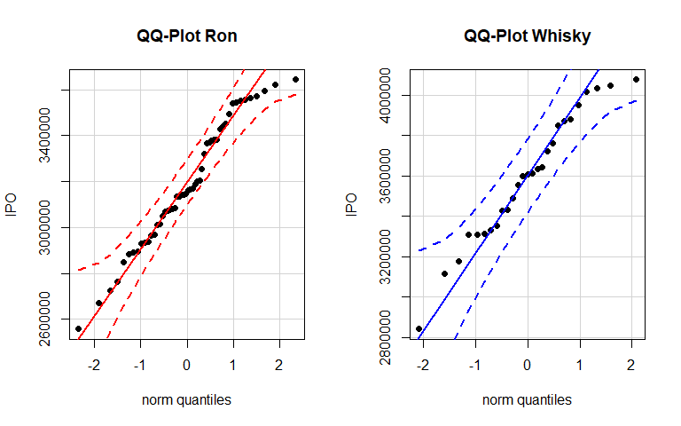

```r
par(mfrow=c(1,2))
with(SoloRW %>% filter(TL=="Ron"),
     qqPlot(IPO,pch=19,main = "QQ-Plot Ron",id=F,col.lines = 2))
with(SoloRW %>% filter(TL=="Whisky"),
     qqPlot(IPO,pch=19,main = "QQ-Plot Whisky",id=F,col.lines = 4))
```

Como ambas muestras distribuyen normal, es necesario verificar si existe igualdad en sus varianzas, esto se comprueba con la función `var.test`.

```r
with(SoloRW,var.test(IPO~TL))
```

```
##
##  F test to compare two variances
##
## data:  IPO by TL
## F = 0.73017, num df = 51, denom df = 26, p-value = 0.3333
## alternative hypothesis: true ratio of variances is not equal to 1
## 95 percent confidence interval:
##  0.3562148 1.3878542
## sample estimates:
## ratio of variances
##           0.730172
```

Entonces, como los datos son normales y tienen varianzas iguales, de acuerdo con el árbol de decisión el mejor estadístico de prueba está basado en la *t-student* y es necesario estimar la varianza conjunta, no obstante, el software lo hace:

```r
with(SoloRW,
     t.test(IPO[TL=="Ron"],
            IPO[TL=="Whisky"],
            var.equal = T,alternative = "less"))
```

```
##
##  Two Sample t-test
##
## data:  IPO[TL == "Ron"] and IPO[TL == "Whisky"]
## t = -5.9561, df = 77, p-value = 3.629e-08
## alternative hypothesis: true difference in means is less than 0
## 95 percent confidence interval:
##       -Inf -292527.9
## sample estimates:
## mean of x mean of y
##   3185673   3591694
```

En conclusión, el ipoconsumo del ron es menor al del whisky con un nivel de significancia del 5%. Entonces la cantidad de impuestos que deja de percibir el departamento tiene mayor aporte en el Whisky, sin embargo, las cantidades de Ron son casi el doble que las de Whisky lo que sugiere que este licor es preferido para la adulteración. Los controles se deben aumentar para incautar más Ron y establecer una estrategia para que no aumente la adulteración del Whisky que es la que más afecta los recursos para salud.

El tercer punto nos piden calcular una nueva variable, si $GAQ=GAE$ el licor se clasifica como **contrabando** en caso contrario se llamará **fraudulento**.

```r
Licores <- Licores %>%
   mutate(TipoLicor = factor(ifelse(GAQ==GAE,"Contrabando","Fraudulento")))
```

Luego preguntan si la proporción de licores Fraudulentos es superior al 65%. Entonces las hipótesis son:

$$H_0: p_F = 0.65 \qquad H_a: p_F >0.65$$

```r
with(Licores,table(TipoLicor))
```

```
## TipoLicor
## Contrabando Fraudulento
##          83         217
```

Como en `R` los factores se organizan alfabéticamente, entonces debemos cambiar la hipótesis hacia los licores de **contrabando**, así:

$$H_0: p_C = 0.35 \qquad H_a: p_C < 0.35$$

```r
with(Licores,
     prop.test(table(TipoLicor),
               p = 0.35,
               alternative = "less",
               conf.level = 0.95,
               correct = F))
```

```
##
##  1-sample proportions test without continuity correction
##
## data:  table(TipoLicor), null probability 0.35
## X-squared = 7.0916, df = 1, p-value = 0.003872
## alternative hypothesis: true p is less than 0.35
## 95 percent confidence interval:
##  0.0000000 0.3210025
## sample estimates:
##         p
## 0.2766667
```

Como el valor-p es mucho menor al nivel de significancia, entonces se rechaza $H_0$ por lo tanto existe evidencia muestral para afirmar que la proporción de licores Fraudulentos es mayor del 65%. Por lo tanto, las rentas ilegales de licores están basadas en mayor medida de la adulteración, el impacto para la salud pública es muy grave, pues los efectos nocivos de los licores que no son correctamente destilados aumenta los riesgos clínicos como la ceguera, el cáncer de órganos digestivos o la muerte.